# Risk Factor Analysis

## Outcome Variable

**Outcome Variable:** wast_rec90d

## Predictor Variables

**Intervention Variable:** mbmi

**Adjustment Set:**

- arm
- W_mage
- meducyrs
- feducyrs
- single
- brthmon
- delta_W_mage
- delta_meducyrs
- delta_feducyrs
- delta_single
- delta_brthmon

## Stratifying Variables

The analysis was stratified on these variable(s):

- agecat
- studyid
- country

## Data Summary

| agecat | studyid | country | mbmi | wast_rec90d | n_cell | n |
| --- | --- | --- | --- | --- | --- | --- |
| 0-24 months | ki0047075b-MAL-ED | BANGLADESH | Normal weight | 0 | 30 | 122 |
| 0-24 months | ki0047075b-MAL-ED | BANGLADESH | Normal weight | 1 | 63 | 122 |
| 0-24 months | ki0047075b-MAL-ED | BANGLADESH | Underweight | 0 | 14 | 122 |
| 0-24 months | ki0047075b-MAL-ED | BANGLADESH | Underweight | 1 | 15 | 122 |
| 0-24 months | ki0047075b-MAL-ED | BRAZIL | Normal weight | 0 | 6 | 23 |
| 0-24 months | ki0047075b-MAL-ED | BRAZIL | Normal weight | 1 | 15 | 23 |
| 0-24 months | ki0047075b-MAL-ED | BRAZIL | Underweight | 0 | 0 | 23 |
| 0-24 months | ki0047075b-MAL-ED | BRAZIL | Underweight | 1 | 2 | 23 |
| 0-24 months | ki0047075b-MAL-ED | INDIA | Normal weight | 0 | 48 | 175 |
| 0-24 months | ki0047075b-MAL-ED | INDIA | Normal weight | 1 | 80 | 175 |
| 0-24 months | ki0047075b-MAL-ED | INDIA | Underweight | 0 | 22 | 175 |
| 0-24 months | ki0047075b-MAL-ED | INDIA | Underweight | 1 | 25 | 175 |
| 0-24 months | ki0047075b-MAL-ED | NEPAL | Normal weight | 0 | 20 | 93 |
| 0-24 months | ki0047075b-MAL-ED | NEPAL | Normal weight | 1 | 73 | 93 |
| 0-24 months | ki0047075b-MAL-ED | NEPAL | Underweight | 0 | 0 | 93 |
| 0-24 months | ki0047075b-MAL-ED | NEPAL | Underweight | 1 | 0 | 93 |
| 0-24 months | ki0047075b-MAL-ED | PERU | Normal weight | 0 | 5 | 34 |
| 0-24 months | ki0047075b-MAL-ED | PERU | Normal weight | 1 | 25 | 34 |
| 0-24 months | ki0047075b-MAL-ED | PERU | Underweight | 0 | 1 | 34 |
| 0-24 months | ki0047075b-MAL-ED | PERU | Underweight | 1 | 3 | 34 |
| 0-24 months | ki0047075b-MAL-ED | SOUTH AFRICA | Normal weight | 0 | 13 | 77 |
| 0-24 months | ki0047075b-MAL-ED | SOUTH AFRICA | Normal weight | 1 | 64 | 77 |
| 0-24 months | ki0047075b-MAL-ED | SOUTH AFRICA | Underweight | 0 | 0 | 77 |
| 0-24 months | ki0047075b-MAL-ED | SOUTH AFRICA | Underweight | 1 | 0 | 77 |
| 0-24 months | ki0047075b-MAL-ED | TANZANIA, UNITED REPUBLIC OF | Normal weight | 0 | 7 | 45 |
| 0-24 months | ki0047075b-MAL-ED | TANZANIA, UNITED REPUBLIC OF | Normal weight | 1 | 34 | 45 |
| 0-24 months | ki0047075b-MAL-ED | TANZANIA, UNITED REPUBLIC OF | Underweight | 0 | 1 | 45 |
| 0-24 months | ki0047075b-MAL-ED | TANZANIA, UNITED REPUBLIC OF | Underweight | 1 | 3 | 45 |
| 0-24 months | ki1000304b-SAS-CompFeed | INDIA | Normal weight | 0 | 287 | 744 |
| 0-24 months | ki1000304b-SAS-CompFeed | INDIA | Normal weight | 1 | 194 | 744 |

[output cut: 158 more lines]

The following strata were considered:

- agecat: 0-24 months, studyid: ki0047075b-MAL-ED, country: BANGLADESH
- agecat: 0-24 months, studyid: ki0047075b-MAL-ED, country: BRAZIL
- agecat: 0-24 months, studyid: ki0047075b-MAL-ED, country: INDIA
- agecat: 0-24 months, studyid: ki0047075b-MAL-ED, country: NEPAL
- agecat: 0-24 months, studyid: ki0047075b-MAL-ED, country: PERU
- agecat: 0-24 months, studyid: ki0047075b-MAL-ED, country: SOUTH AFRICA
- agecat: 0-24 months, studyid: ki0047075b-MAL-ED, country: TANZANIA, UNITED REPUBLIC OF
- agecat: 0-24 months, studyid: ki1000304b-SAS-CompFeed, country: INDIA
- agecat: 0-24 months, studyid: ki1017093-NIH-Birth, country: BANGLADESH
- agecat: 0-24 months, studyid: ki1017093b-PROVIDE, country: BANGLADESH
- agecat: 0-24 months, studyid: ki1017093c-NIH-Crypto, country: BANGLADESH
- agecat: 0-24 months, studyid: ki1066203-TanzaniaChild2, country: TANZANIA, UNITED REPUBLIC OF
- agecat: 0-24 months, studyid: ki1112895-iLiNS-Zinc, country: BURKINA FASO
- agecat: 0-24 months, studyid: ki1119695-PROBIT, country: BELARUS
- agecat: 0-24 months, studyid: ki1126311-ZVITAMBO, country: ZIMBABWE
- agecat: 0-24 months, studyid: ki1148112-LCNI-5, country: MALAWI
- agecat: 0-6 months, studyid: ki0047075b-MAL-ED, country: BANGLADESH
- agecat: 0-6 months, studyid: ki0047075b-MAL-ED, country: BRAZIL
- agecat: 0-6 months, studyid: ki0047075b-MAL-ED, country: INDIA
- agecat: 0-6 months, studyid: ki0047075b-MAL-ED, country: NEPAL
- agecat: 0-6 months, studyid: ki0047075b-MAL-ED, country: PERU
- agecat: 0-6 months, studyid: ki0047075b-MAL-ED, country: SOUTH AFRICA
- agecat: 0-6 months, studyid: ki0047075b-MAL-ED, country: TANZANIA, UNITED REPUBLIC OF
- agecat: 0-6 months, studyid: ki1000304b-SAS-CompFeed, country: INDIA
- agecat: 0-6 months, studyid: ki1017093-NIH-Birth, country: BANGLADESH
- agecat: 0-6 months, studyid: ki1017093b-PROVIDE, country: BANGLADESH
- agecat: 0-6 months, studyid: ki1017093c-NIH-Crypto, country: BANGLADESH
- agecat: 0-6 months, studyid: ki1066203-TanzaniaChild2, country: TANZANIA, UNITED REPUBLIC OF
- agecat: 0-6 months, studyid: ki1119695-PROBIT, country: BELARUS
- agecat: 0-6 months, studyid: ki1126311-ZVITAMBO, country: ZIMBABWE
- agecat: 0-6 months, studyid: ki1148112-LCNI-5, country: MALAWI
- agecat: 6-24 months, studyid: ki0047075b-MAL-ED, country: BANGLADESH
- agecat: 6-24 months, studyid: ki0047075b-MAL-ED, country: BRAZIL
- agecat: 6-24 months, studyid: ki0047075b-MAL-ED, country: INDIA
- agecat: 6-24 months, studyid: ki0047075b-MAL-ED, country: NEPAL
- agecat: 6-24 months, studyid: ki0047075b-MAL-ED, country: PERU
- agecat: 6-24 months, studyid: ki0047075b-MAL-ED, country: SOUTH AFRICA
- agecat: 6-24 months, studyid: ki0047075b-MAL-ED, country: TANZANIA, UNITED REPUBLIC OF
- agecat: 6-24 months, studyid: ki1000304b-SAS-CompFeed, country: INDIA
- agecat: 6-24 months, studyid: ki1017093-NIH-Birth, country: BANGLADESH
- agecat: 6-24 months, studyid: ki1017093b-PROVIDE, country: BANGLADESH
- agecat: 6-24 months, studyid: ki1017093c-NIH-Crypto, country: BANGLADESH
- agecat: 6-24 months, studyid: ki1066203-TanzaniaChild2, country: TANZANIA, UNITED REPUBLIC OF
- agecat: 6-24 months, studyid: ki1112895-iLiNS-Zinc, country: BURKINA FASO
- agecat: 6-24 months, studyid: ki1119695-PROBIT, country: BELARUS
- agecat: 6-24 months, studyid: ki1126311-ZVITAMBO, country: ZIMBABWE
- agecat: 6-24 months, studyid: ki1148112-LCNI-5, country: MALAWI

### Dropped Strata

Some strata were dropped due to rare outcomes:

- agecat: 0-24 months, studyid: ki0047075b-MAL-ED, country: BRAZIL
- agecat: 0-24 months, studyid: ki0047075b-MAL-ED, country: NEPAL
- agecat: 0-24 months, studyid: ki0047075b-MAL-ED, country: PERU
- agecat: 0-24 months, studyid: ki0047075b-MAL-ED, country: SOUTH AFRICA
- agecat: 0-24 months, studyid: ki0047075b-MAL-ED, country: TANZANIA, UNITED REPUBLIC OF
- agecat: 0-6 months, studyid: ki0047075b-MAL-ED, country: BRAZIL
- agecat: 0-6 months, studyid: ki0047075b-MAL-ED, country: NEPAL
- agecat: 0-6 months, studyid: ki0047075b-MAL-ED, country: PERU
- agecat: 0-6 months, studyid: ki0047075b-MAL-ED, country: SOUTH AFRICA
- agecat: 0-6 months, studyid: ki0047075b-MAL-ED, country: TANZANIA, UNITED REPUBLIC OF
- agecat: 0-6 months, studyid: ki1017093c-NIH-Crypto, country: BANGLADESH
- agecat: 0-6 months, studyid: ki1066203-TanzaniaChild2, country: TANZANIA, UNITED REPUBLIC OF
- agecat: 0-6 months, studyid: ki1148112-LCNI-5, country: MALAWI
- agecat: 6-24 months, studyid: ki0047075b-MAL-ED, country: BRAZIL
- agecat: 6-24 months, studyid: ki0047075b-MAL-ED, country: NEPAL
- agecat: 6-24 months, studyid: ki0047075b-MAL-ED, country: PERU
- agecat: 6-24 months, studyid: ki0047075b-MAL-ED, country: SOUTH AFRICA
- agecat: 6-24 months, studyid: ki0047075b-MAL-ED, country: TANZANIA, UNITED REPUBLIC OF
- agecat: 6-24 months, studyid: ki1017093c-NIH-Crypto, country: BANGLADESH
- agecat: 6-24 months, studyid: ki1066203-TanzaniaChild2, country: TANZANIA, UNITED REPUBLIC OF
- agecat: 6-24 months, studyid: ki1119695-PROBIT, country: BELARUS

## Methods Detail

We’re interested in the causal parameters $E[Y_a]$ for all values of $a \in \mathcal{A}$. These parameters represent the mean outcome if, possibly contrary to fact, we intervened to set all units to have $A=a$. Under the randomization and positivity assumptions, these are identified by the statistical parameters $\psi_a=E_W[E_{Y|A,W}(Y|A=a,W)]$. In addition, we’re interested in the mean of $Y$, $E[Y]$ under no intervention (the observed mean). We will estimate these parameters by using SuperLearner to fit the relevant likelihood factors – $E_{Y|A,W}(Y|A=a,W)$ and $p(A=a|W)$, and then updating our likelihood fit using a joint TMLE.

For unadjusted analyses ($W=\{\}$), initial likelihoods were estimated using Lrnr_glm to estimate the simple $E(Y|A)$ and Lrnr_mean to estimate $p(A)$. For adjusted analyses, a small library containing Lrnr_glmnet, Lrnr_xgboost, and Lrnr_mean was used.

Having estimated these parameters, we will then use the delta method to estimate relative risks and attributable risks relative to a prespecified baseline level of $A$.

# Results Detail

## Results Plots

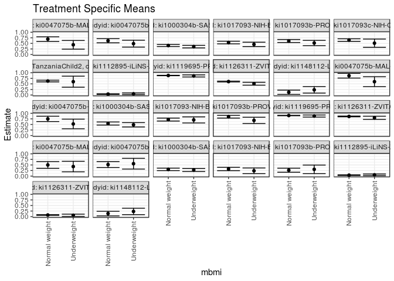

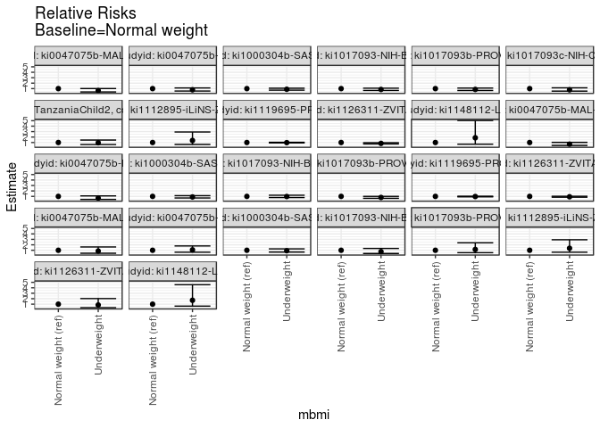

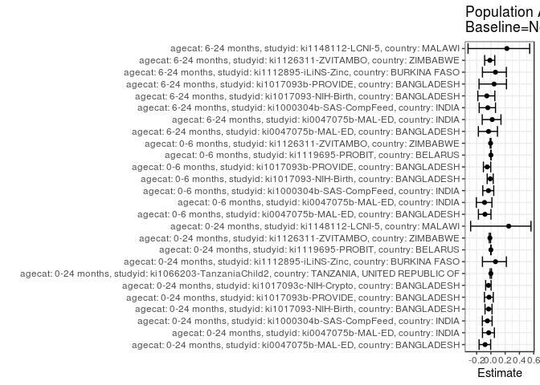

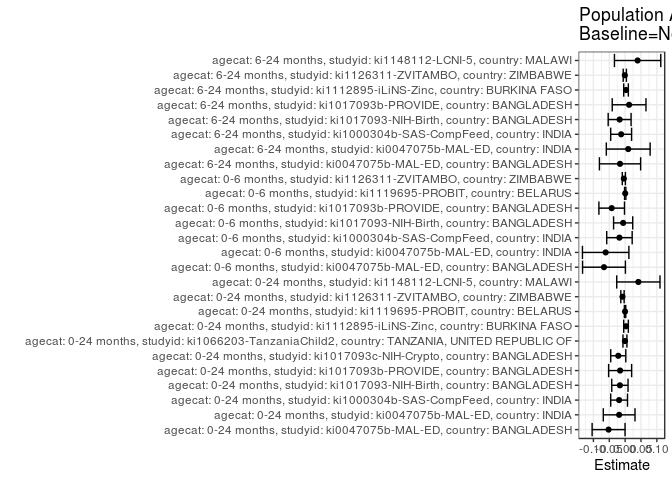

## Results Table

### Parameter: TSM

| agecat | studyid | country | intervention_level | baseline_level | estimate | ci_lower | ci_upper |
| --- | --- | --- | --- | --- | --- | --- | --- |
| 0-24 months | ki0047075b-MAL-ED | BANGLADESH | Normal weight | NA | 0.6915268 | 0.5868746 | 0.7961789 |
| 0-24 months | ki0047075b-MAL-ED | BANGLADESH | Underweight | NA | 0.4362134 | 0.2411872 | 0.6312396 |
| 0-24 months | ki0047075b-MAL-ED | INDIA | Normal weight | NA | 0.6188647 | 0.5249105 | 0.7128189 |
| 0-24 months | ki0047075b-MAL-ED | INDIA | Underweight | NA | 0.4879315 | 0.3321508 | 0.6437121 |
| 0-24 months | ki1000304b-SAS-CompFeed | INDIA | Normal weight | NA | 0.4034109 | 0.3561539 | 0.4506679 |
| 0-24 months | ki1000304b-SAS-CompFeed | INDIA | Underweight | NA | 0.3546255 | 0.2973067 | 0.4119443 |
| 0-24 months | ki1017093-NIH-Birth | BANGLADESH | Normal weight | NA | 0.5367576 | 0.4780763 | 0.5954390 |
| 0-24 months | ki1017093-NIH-Birth | BANGLADESH | Underweight | NA | 0.4539835 | 0.3548591 | 0.5531078 |
| 0-24 months | ki1017093b-PROVIDE | BANGLADESH | Normal weight | NA | 0.6051938 | 0.5383342 | 0.6720534 |
| 0-24 months | ki1017093b-PROVIDE | BANGLADESH | Underweight | NA | 0.5165096 | 0.3973365 | 0.6356827 |
| 0-24 months | ki1017093c-NIH-Crypto | BANGLADESH | Normal weight | NA | 0.6474663 | 0.5898151 | 0.7051175 |
| 0-24 months | ki1017093c-NIH-Crypto | BANGLADESH | Underweight | NA | 0.5090570 | 0.3234308 | 0.6946832 |
| 0-24 months | ki1066203-TanzaniaChild2 | TANZANIA, UNITED REPUBLIC OF | Normal weight | NA | 0.6288210 | 0.5904220 | 0.6672199 |
| 0-24 months | ki1066203-TanzaniaChild2 | TANZANIA, UNITED REPUBLIC OF | Underweight | NA | 0.6000000 | 0.3523180 | 0.8476820 |
| 0-24 months | ki1112895-iLiNS-Zinc | BURKINA FASO | Normal weight | NA | 0.0407524 | 0.0253994 | 0.0561053 |
| 0-24 months | ki1112895-iLiNS-Zinc | BURKINA FASO | Underweight | NA | 0.0559441 | 0.0192211 | 0.0926670 |
| 0-24 months | ki1119695-PROBIT | BELARUS | Normal weight | NA | 0.8771754 | 0.8667782 | 0.8875726 |
| 0-24 months | ki1119695-PROBIT | BELARUS | Underweight | NA | 0.8581795 | 0.8100980 | 0.9062609 |
| 0-24 months | ki1126311-ZVITAMBO | ZIMBABWE | Normal weight | NA | 0.6051661 | 0.5857689 | 0.6245633 |
| 0-24 months | ki1126311-ZVITAMBO | ZIMBABWE | Underweight | NA | 0.5076813 | 0.4420696 | 0.5732930 |
| 0-24 months | ki1148112-LCNI-5 | MALAWI | Normal weight | NA | 0.1250000 | 0.0290888 | 0.2209112 |
| 0-24 months | ki1148112-LCNI-5 | MALAWI | Underweight | NA | 0.2333333 | 0.0868920 | 0.3797747 |
| 0-6 months | ki0047075b-MAL-ED | BANGLADESH | Normal weight | NA | 0.8666667 | 0.7613735 | 0.9719599 |
| 0-6 months | ki0047075b-MAL-ED | BANGLADESH | Underweight | NA | 0.6000000 | 0.3771424 | 0.8228576 |
| 0-6 months | ki0047075b-MAL-ED | INDIA | Normal weight | NA | 0.7488977 | 0.6287792 | 0.8690161 |
| 0-6 months | ki0047075b-MAL-ED | INDIA | Underweight | NA | 0.5218562 | 0.3055128 | 0.7381996 |
| 0-6 months | ki1000304b-SAS-CompFeed | INDIA | Normal weight | NA | 0.5408289 | 0.4719739 | 0.6096839 |
| 0-6 months | ki1000304b-SAS-CompFeed | INDIA | Underweight | NA | 0.4839494 | 0.3861955 | 0.5817033 |
| 0-6 months | ki1017093-NIH-Birth | BANGLADESH | Normal weight | NA | 0.7192898 | 0.6525673 | 0.7860123 |
| 0-6 months | ki1017093-NIH-Birth | BANGLADESH | Underweight | NA | 0.7021194 | 0.5654883 | 0.8387504 |
| 0-6 months | ki1017093b-PROVIDE | BANGLADESH | Normal weight | NA | 0.8468581 | 0.7858231 | 0.9078930 |
| 0-6 months | ki1017093b-PROVIDE | BANGLADESH | Underweight | NA | 0.6819457 | 0.5415664 | 0.8223250 |
| 0-6 months | ki1119695-PROBIT | BELARUS | Normal weight | NA | 0.8998587 | 0.8899970 | 0.9097205 |
| 0-6 months | ki1119695-PROBIT | BELARUS | Underweight | NA | 0.8766961 | 0.8295667 | 0.9238256 |
| 0-6 months | ki1126311-ZVITAMBO | ZIMBABWE | Normal weight | NA | 0.8587431 | 0.8420914 | 0.8753948 |
| 0-6 months | ki1126311-ZVITAMBO | ZIMBABWE | Underweight | NA | 0.7977384 | 0.7259066 | 0.8695702 |
| 6-24 months | ki0047075b-MAL-ED | BANGLADESH | Normal weight | NA | 0.5000000 | 0.3485042 | 0.6514958 |
| 6-24 months | ki0047075b-MAL-ED | BANGLADESH | Underweight | NA | 0.4285714 | 0.1923941 | 0.6647488 |
| 6-24 months | ki0047075b-MAL-ED | INDIA | Normal weight | NA | 0.5165774 | 0.3832338 | 0.6499210 |
| 6-24 months | ki0047075b-MAL-ED | INDIA | Underweight | NA | 0.5574072 | 0.3165396 | 0.7982748 |
| 6-24 months | ki1000304b-SAS-CompFeed | INDIA | Normal weight | NA | 0.3002892 | 0.2444777 | 0.3561007 |
| 6-24 months | ki1000304b-SAS-CompFeed | INDIA | Underweight | NA | 0.2760733 | 0.2075369 | 0.3446097 |
| 6-24 months | ki1017093-NIH-Birth | BANGLADESH | Normal weight | NA | 0.3203880 | 0.2438160 | 0.3969599 |
| 6-24 months | ki1017093-NIH-Birth | BANGLADESH | Underweight | NA | 0.2384313 | 0.1112891 | 0.3655736 |
| 6-24 months | ki1017093b-PROVIDE | BANGLADESH | Normal weight | NA | 0.2639583 | 0.1734832 | 0.3544334 |
| 6-24 months | ki1017093b-PROVIDE | BANGLADESH | Underweight | NA | 0.3031191 | 0.1108350 | 0.4954032 |
| 6-24 months | ki1112895-iLiNS-Zinc | BURKINA FASO | Normal weight | NA | 0.0407524 | 0.0253994 | 0.0561053 |
| 6-24 months | ki1112895-iLiNS-Zinc | BURKINA FASO | Underweight | NA | 0.0559441 | 0.0192211 | 0.0926670 |
| 6-24 months | ki1126311-ZVITAMBO | ZIMBABWE | Normal weight | NA | 0.0716981 | 0.0538446 | 0.0895517 |
| 6-24 months | ki1126311-ZVITAMBO | ZIMBABWE | Underweight | NA | 0.0609756 | 0.0103160 | 0.1116352 |
| 6-24 months | ki1148112-LCNI-5 | MALAWI | Normal weight | NA | 0.1363636 | 0.0329768 | 0.2397505 |
| 6-24 months | ki1148112-LCNI-5 | MALAWI | Underweight | NA | 0.2333333 | 0.0877343 | 0.3789324 |

### Parameter: E(Y)

| agecat | studyid | country | intervention_level | baseline_level | estimate | ci_lower | ci_upper |
| --- | --- | --- | --- | --- | --- | --- | --- |
| 0-24 months | ki0047075b-MAL-ED | BANGLADESH | NA | NA | 0.6393443 | 0.5530901 | 0.7255985 |
| 0-24 months | ki0047075b-MAL-ED | INDIA | NA | NA | 0.6000000 | 0.5192868 | 0.6807132 |
| 0-24 months | ki1000304b-SAS-CompFeed | INDIA | NA | NA | 0.3844086 | 0.3477135 | 0.4211037 |
| 0-24 months | ki1017093-NIH-Birth | BANGLADESH | NA | NA | 0.5201900 | 0.4695846 | 0.5707955 |
| 0-24 months | ki1017093b-PROVIDE | BANGLADESH | NA | NA | 0.5894040 | 0.5323948 | 0.6464131 |
| 0-24 months | ki1017093c-NIH-Crypto | BANGLADESH | NA | NA | 0.6258065 | 0.5718723 | 0.6797406 |
| 0-24 months | ki1066203-TanzaniaChild2 | TANZANIA, UNITED REPUBLIC OF | NA | NA | 0.6282051 | 0.5902579 | 0.6661523 |
| 0-24 months | ki1112895-iLiNS-Zinc | BURKINA FASO | NA | NA | 0.0435339 | 0.0292984 | 0.0577695 |
| 0-24 months | ki1119695-PROBIT | BELARUS | NA | NA | 0.8768959 | 0.8667536 | 0.8870382 |
| 0-24 months | ki1126311-ZVITAMBO | ZIMBABWE | NA | NA | 0.5967742 | 0.5781484 | 0.6154000 |
| 0-24 months | ki1148112-LCNI-5 | MALAWI | NA | NA | 0.1666667 | 0.0842830 | 0.2490503 |
| 0-6 months | ki0047075b-MAL-ED | BANGLADESH | NA | NA | 0.8000000 | 0.6995926 | 0.9004074 |
| 0-6 months | ki0047075b-MAL-ED | INDIA | NA | NA | 0.6875000 | 0.5825226 | 0.7924774 |
| 0-6 months | ki1000304b-SAS-CompFeed | INDIA | NA | NA | 0.5228758 | 0.4664267 | 0.5793250 |
| 0-6 months | ki1017093-NIH-Birth | BANGLADESH | NA | NA | 0.7130045 | 0.6535890 | 0.7724200 |
| 0-6 months | ki1017093b-PROVIDE | BANGLADESH | NA | NA | 0.8044693 | 0.7471161 | 0.8618224 |
| 0-6 months | ki1119695-PROBIT | BELARUS | NA | NA | 0.9001049 | 0.8905121 | 0.9096977 |
| 0-6 months | ki1126311-ZVITAMBO | ZIMBABWE | NA | NA | 0.8546674 | 0.8383989 | 0.8709359 |
| 6-24 months | ki0047075b-MAL-ED | BANGLADESH | NA | NA | 0.4838710 | 0.3544124 | 0.6133295 |
| 6-24 months | ki0047075b-MAL-ED | INDIA | NA | NA | 0.5263158 | 0.4116286 | 0.6410029 |
| 6-24 months | ki1000304b-SAS-CompFeed | INDIA | NA | NA | 0.2876712 | 0.2441703 | 0.3311721 |
| 6-24 months | ki1017093-NIH-Birth | BANGLADESH | NA | NA | 0.3030303 | 0.2377927 | 0.3682679 |
| 6-24 months | ki1017093b-PROVIDE | BANGLADESH | NA | NA | 0.2764228 | 0.1950773 | 0.3577682 |
| 6-24 months | ki1112895-iLiNS-Zinc | BURKINA FASO | NA | NA | 0.0435339 | 0.0292984 | 0.0577695 |
| 6-24 months | ki1126311-ZVITAMBO | ZIMBABWE | NA | NA | 0.0706956 | 0.0538314 | 0.0875597 |
| 6-24 months | ki1148112-LCNI-5 | MALAWI | NA | NA | 0.1756757 | 0.0897916 | 0.2615597 |

### Parameter: RR

| agecat | studyid | country | intervention_level | baseline_level | estimate | ci_lower | ci_upper |
| --- | --- | --- | --- | --- | --- | --- | --- |
| 0-24 months | ki0047075b-MAL-ED | BANGLADESH | Normal weight | Normal weight | 1.0000000 | 1.0000000 | 1.0000000 |
| 0-24 months | ki0047075b-MAL-ED | BANGLADESH | Underweight | Normal weight | 0.6307976 | 0.3935149 | 1.0111575 |
| 0-24 months | ki0047075b-MAL-ED | INDIA | Normal weight | Normal weight | 1.0000000 | 1.0000000 | 1.0000000 |
| 0-24 months | ki0047075b-MAL-ED | INDIA | Underweight | Normal weight | 0.7884300 | 0.5528225 | 1.1244512 |
| 0-24 months | ki1000304b-SAS-CompFeed | INDIA | Normal weight | Normal weight | 1.0000000 | 1.0000000 | 1.0000000 |
| 0-24 months | ki1000304b-SAS-CompFeed | INDIA | Underweight | Normal weight | 0.8790676 | 0.7199781 | 1.0733102 |
| 0-24 months | ki1017093-NIH-Birth | BANGLADESH | Normal weight | Normal weight | 1.0000000 | 1.0000000 | 1.0000000 |
| 0-24 months | ki1017093-NIH-Birth | BANGLADESH | Underweight | Normal weight | 0.8457885 | 0.6625352 | 1.0797286 |
| 0-24 months | ki1017093b-PROVIDE | BANGLADESH | Normal weight | Normal weight | 1.0000000 | 1.0000000 | 1.0000000 |
| 0-24 months | ki1017093b-PROVIDE | BANGLADESH | Underweight | Normal weight | 0.8534615 | 0.6601592 | 1.1033651 |
| 0-24 months | ki1017093c-NIH-Crypto | BANGLADESH | Normal weight | Normal weight | 1.0000000 | 1.0000000 | 1.0000000 |
| 0-24 months | ki1017093c-NIH-Crypto | BANGLADESH | Underweight | Normal weight | 0.7862293 | 0.5400881 | 1.1445475 |
| 0-24 months | ki1066203-TanzaniaChild2 | TANZANIA, UNITED REPUBLIC OF | Normal weight | Normal weight | 1.0000000 | 1.0000000 | 1.0000000 |
| 0-24 months | ki1066203-TanzaniaChild2 | TANZANIA, UNITED REPUBLIC OF | Underweight | Normal weight | 0.9541667 | 0.6286319 | 1.4482784 |
| 0-24 months | ki1112895-iLiNS-Zinc | BURKINA FASO | Normal weight | Normal weight | 1.0000000 | 1.0000000 | 1.0000000 |
| 0-24 months | ki1112895-iLiNS-Zinc | BURKINA FASO | Underweight | Normal weight | 1.3727811 | 0.6440241 | 2.9261761 |
| 0-24 months | ki1119695-PROBIT | BELARUS | Normal weight | Normal weight | 1.0000000 | 1.0000000 | 1.0000000 |
| 0-24 months | ki1119695-PROBIT | BELARUS | Underweight | Normal weight | 0.9783442 | 0.9238941 | 1.0360034 |
| 0-24 months | ki1126311-ZVITAMBO | ZIMBABWE | Normal weight | Normal weight | 1.0000000 | 1.0000000 | 1.0000000 |
| 0-24 months | ki1126311-ZVITAMBO | ZIMBABWE | Underweight | Normal weight | 0.8389123 | 0.7343227 | 0.9583987 |
| 0-24 months | ki1148112-LCNI-5 | MALAWI | Normal weight | Normal weight | 1.0000000 | 1.0000000 | 1.0000000 |
| 0-24 months | ki1148112-LCNI-5 | MALAWI | Underweight | Normal weight | 1.8666667 | 0.6926702 | 5.0304525 |
| 0-6 months | ki0047075b-MAL-ED | BANGLADESH | Normal weight | Normal weight | 1.0000000 | 1.0000000 | 1.0000000 |
| 0-6 months | ki0047075b-MAL-ED | BANGLADESH | Underweight | Normal weight | 0.6923077 | 0.4683665 | 1.0233224 |
| 0-6 months | ki0047075b-MAL-ED | INDIA | Normal weight | Normal weight | 1.0000000 | 1.0000000 | 1.0000000 |
| 0-6 months | ki0047075b-MAL-ED | INDIA | Underweight | Normal weight | 0.6968324 | 0.4464527 | 1.0876302 |
| 0-6 months | ki1000304b-SAS-CompFeed | INDIA | Normal weight | Normal weight | 1.0000000 | 1.0000000 | 1.0000000 |
| 0-6 months | ki1000304b-SAS-CompFeed | INDIA | Underweight | Normal weight | 0.8948290 | 0.7054557 | 1.1350378 |
| 0-6 months | ki1017093-NIH-Birth | BANGLADESH | Normal weight | Normal weight | 1.0000000 | 1.0000000 | 1.0000000 |
| 0-6 months | ki1017093-NIH-Birth | BANGLADESH | Underweight | Normal weight | 0.9761286 | 0.7865022 | 1.2114743 |
| 0-6 months | ki1017093b-PROVIDE | BANGLADESH | Normal weight | Normal weight | 1.0000000 | 1.0000000 | 1.0000000 |
| 0-6 months | ki1017093b-PROVIDE | BANGLADESH | Underweight | Normal weight | 0.8052656 | 0.6472350 | 1.0018814 |
| 0-6 months | ki1119695-PROBIT | BELARUS | Normal weight | Normal weight | 1.0000000 | 1.0000000 | 1.0000000 |
| 0-6 months | ki1119695-PROBIT | BELARUS | Underweight | Normal weight | 0.9742597 | 0.9222476 | 1.0292052 |
| 0-6 months | ki1126311-ZVITAMBO | ZIMBABWE | Normal weight | Normal weight | 1.0000000 | 1.0000000 | 1.0000000 |
| 0-6 months | ki1126311-ZVITAMBO | ZIMBABWE | Underweight | Normal weight | 0.9289605 | 0.8472099 | 1.0185995 |
| 6-24 months | ki0047075b-MAL-ED | BANGLADESH | Normal weight | Normal weight | 1.0000000 | 1.0000000 | 1.0000000 |
| 6-24 months | ki0047075b-MAL-ED | BANGLADESH | Underweight | Normal weight | 0.8571429 | 0.4568613 | 1.6081334 |
| 6-24 months | ki0047075b-MAL-ED | INDIA | Normal weight | Normal weight | 1.0000000 | 1.0000000 | 1.0000000 |
| 6-24 months | ki0047075b-MAL-ED | INDIA | Underweight | Normal weight | 1.0790391 | 0.6493070 | 1.7931817 |
| 6-24 months | ki1000304b-SAS-CompFeed | INDIA | Normal weight | Normal weight | 1.0000000 | 1.0000000 | 1.0000000 |
| 6-24 months | ki1000304b-SAS-CompFeed | INDIA | Underweight | Normal weight | 0.9193580 | 0.6729156 | 1.2560551 |
| 6-24 months | ki1017093-NIH-Birth | BANGLADESH | Normal weight | Normal weight | 1.0000000 | 1.0000000 | 1.0000000 |
| 6-24 months | ki1017093-NIH-Birth | BANGLADESH | Underweight | Normal weight | 0.7441957 | 0.4142416 | 1.3369667 |
| 6-24 months | ki1017093b-PROVIDE | BANGLADESH | Normal weight | Normal weight | 1.0000000 | 1.0000000 | 1.0000000 |
| 6-24 months | ki1017093b-PROVIDE | BANGLADESH | Underweight | Normal weight | 1.1483598 | 0.5570520 | 2.3673378 |
| 6-24 months | ki1112895-iLiNS-Zinc | BURKINA FASO | Normal weight | Normal weight | 1.0000000 | 1.0000000 | 1.0000000 |
| 6-24 months | ki1112895-iLiNS-Zinc | BURKINA FASO | Underweight | Normal weight | 1.3727811 | 0.6440241 | 2.9261761 |
| 6-24 months | ki1126311-ZVITAMBO | ZIMBABWE | Normal weight | Normal weight | 1.0000000 | 1.0000000 | 1.0000000 |
| 6-24 months | ki1126311-ZVITAMBO | ZIMBABWE | Underweight | Normal weight | 0.8504493 | 0.3572482 | 2.0245419 |
| 6-24 months | ki1148112-LCNI-5 | MALAWI | Normal weight | Normal weight | 1.0000000 | 1.0000000 | 1.0000000 |
| 6-24 months | ki1148112-LCNI-5 | MALAWI | Underweight | Normal weight | 1.7111111 | 0.6408783 | 4.5685760 |

### Parameter: PAR

| agecat | studyid | country | intervention_level | baseline_level | estimate | ci_lower | ci_upper |
| --- | --- | --- | --- | --- | --- | --- | --- |
| 0-24 months | ki0047075b-MAL-ED | BANGLADESH | Normal weight | NA | -0.0521825 | -0.1040935 | -0.0002715 |
| 0-24 months | ki0047075b-MAL-ED | INDIA | Normal weight | NA | -0.0188647 | -0.0688319 | 0.0311026 |
| 0-24 months | ki1000304b-SAS-CompFeed | INDIA | Normal weight | NA | -0.0190023 | -0.0454647 | 0.0074600 |
| 0-24 months | ki1017093-NIH-Birth | BANGLADESH | Normal weight | NA | -0.0165676 | -0.0422406 | 0.0091054 |
| 0-24 months | ki1017093b-PROVIDE | BANGLADESH | Normal weight | NA | -0.0157898 | -0.0520617 | 0.0204821 |
| 0-24 months | ki1017093c-NIH-Crypto | BANGLADESH | Normal weight | NA | -0.0216599 | -0.0454209 | 0.0021012 |
| 0-24 months | ki1066203-TanzaniaChild2 | TANZANIA, UNITED REPUBLIC OF | Normal weight | NA | -0.0006158 | -0.0068812 | 0.0056495 |
| 0-24 months | ki1112895-iLiNS-Zinc | BURKINA FASO | Normal weight | NA | 0.0027816 | -0.0045144 | 0.0100776 |
| 0-24 months | ki1119695-PROBIT | BELARUS | Normal weight | NA | -0.0002796 | -0.0024614 | 0.0019023 |
| 0-24 months | ki1126311-ZVITAMBO | ZIMBABWE | Normal weight | NA | -0.0083919 | -0.0135898 | -0.0031941 |
| 0-24 months | ki1148112-LCNI-5 | MALAWI | Normal weight | NA | 0.0416667 | -0.0265326 | 0.1098659 |
| 0-6 months | ki0047075b-MAL-ED | BANGLADESH | Normal weight | NA | -0.0666667 | -0.1342155 | 0.0008822 |
| 0-6 months | ki0047075b-MAL-ED | INDIA | Normal weight | NA | -0.0613977 | -0.1345683 | 0.0117730 |
| 0-6 months | ki1000304b-SAS-CompFeed | INDIA | Normal weight | NA | -0.0179531 | -0.0580645 | 0.0221583 |
| 0-6 months | ki1017093-NIH-Birth | BANGLADESH | Normal weight | NA | -0.0062853 | -0.0364485 | 0.0238779 |
| 0-6 months | ki1017093b-PROVIDE | BANGLADESH | Normal weight | NA | -0.0423888 | -0.0827364 | -0.0020412 |
| 0-6 months | ki1119695-PROBIT | BELARUS | Normal weight | NA | 0.0002461 | -0.0018093 | 0.0023015 |
| 0-6 months | ki1126311-ZVITAMBO | ZIMBABWE | Normal weight | NA | -0.0040757 | -0.0089962 | 0.0008449 |
| 6-24 months | ki0047075b-MAL-ED | BANGLADESH | Normal weight | NA | -0.0161290 | -0.0810894 | 0.0488313 |
| 6-24 months | ki0047075b-MAL-ED | INDIA | Normal weight | NA | 0.0097384 | -0.0593074 | 0.0787842 |
| 6-24 months | ki1000304b-SAS-CompFeed | INDIA | Normal weight | NA | -0.0126180 | -0.0455186 | 0.0202827 |
| 6-24 months | ki1017093-NIH-Birth | BANGLADESH | Normal weight | NA | -0.0173577 | -0.0534513 | 0.0187360 |
| 6-24 months | ki1017093b-PROVIDE | BANGLADESH | Normal weight | NA | 0.0124645 | -0.0407232 | 0.0656521 |
| 6-24 months | ki1112895-iLiNS-Zinc | BURKINA FASO | Normal weight | NA | 0.0027816 | -0.0045144 | 0.0100776 |
| 6-24 months | ki1126311-ZVITAMBO | ZIMBABWE | Normal weight | NA | -0.0010026 | -0.0060302 | 0.0040251 |
| 6-24 months | ki1148112-LCNI-5 | MALAWI | Normal weight | NA | 0.0393120 | -0.0337215 | 0.1123456 |

### Parameter: PAF

| agecat | studyid | country | intervention_level | baseline_level | estimate | ci_lower | ci_upper |
| --- | --- | --- | --- | --- | --- | --- | --- |
| 0-24 months | ki0047075b-MAL-ED | BANGLADESH | Normal weight | NA | -0.0816188 | -0.1656590 | -0.0036376 |
| 0-24 months | ki0047075b-MAL-ED | INDIA | Normal weight | NA | -0.0314411 | -0.1183949 | 0.0487521 |
| 0-24 months | ki1000304b-SAS-CompFeed | INDIA | Normal weight | NA | -0.0494326 | -0.1202682 | 0.0169239 |
| 0-24 months | ki1017093-NIH-Birth | BANGLADESH | Normal weight | NA | -0.0318492 | -0.0822238 | 0.0161807 |
| 0-24 months | ki1017093b-PROVIDE | BANGLADESH | Normal weight | NA | -0.0267894 | -0.0903323 | 0.0330503 |
| 0-24 months | ki1017093c-NIH-Crypto | BANGLADESH | Normal weight | NA | -0.0346111 | -0.0735864 | 0.0029492 |
| 0-24 months | ki1066203-TanzaniaChild2 | TANZANIA, UNITED REPUBLIC OF | Normal weight | NA | -0.0009803 | -0.0110044 | 0.0089444 |
| 0-24 months | ki1112895-iLiNS-Zinc | BURKINA FASO | Normal weight | NA | 0.0638945 | -0.1187672 | 0.2167329 |
| 0-24 months | ki1119695-PROBIT | BELARUS | Normal weight | NA | -0.0003188 | -0.0028100 | 0.0021663 |
| 0-24 months | ki1126311-ZVITAMBO | ZIMBABWE | Normal weight | NA | -0.0140621 | -0.0228154 | -0.0053838 |
| 0-24 months | ki1148112-LCNI-5 | MALAWI | Normal weight | NA | 0.2500000 | -0.2838955 | 0.5618802 |
| 0-6 months | ki0047075b-MAL-ED | BANGLADESH | Normal weight | NA | -0.0833333 | -0.1747478 | 0.0009676 |
| 0-6 months | ki0047075b-MAL-ED | INDIA | Normal weight | NA | -0.0893057 | -0.2039454 | 0.0144180 |
| 0-6 months | ki1000304b-SAS-CompFeed | INDIA | Normal weight | NA | -0.0343353 | -0.1141090 | 0.0397263 |
| 0-6 months | ki1017093-NIH-Birth | BANGLADESH | Normal weight | NA | -0.0088152 | -0.0520233 | 0.0326182 |
| 0-6 months | ki1017093b-PROVIDE | BANGLADESH | Normal weight | NA | -0.0526916 | -0.1052102 | -0.0026687 |
| 0-6 months | ki1119695-PROBIT | BELARUS | Normal weight | NA | 0.0002735 | -0.0020127 | 0.0025544 |
| 0-6 months | ki1126311-ZVITAMBO | ZIMBABWE | Normal weight | NA | -0.0047687 | -0.0105499 | 0.0009793 |
| 6-24 months | ki0047075b-MAL-ED | BANGLADESH | Normal weight | NA | -0.0333333 | -0.1758408 | 0.0919028 |
| 6-24 months | ki0047075b-MAL-ED | INDIA | Normal weight | NA | 0.0185030 | -0.1218855 | 0.1413237 |
| 6-24 months | ki1000304b-SAS-CompFeed | INDIA | Normal weight | NA | -0.0438624 | -0.1645839 | 0.0643450 |
| 6-24 months | ki1017093-NIH-Birth | BANGLADESH | Normal weight | NA | -0.0572803 | -0.1831796 | 0.0552224 |
| 6-24 months | ki1017093b-PROVIDE | BANGLADESH | Normal weight | NA | 0.0450920 | -0.1662683 | 0.2181480 |
| 6-24 months | ki1112895-iLiNS-Zinc | BURKINA FASO | Normal weight | NA | 0.0638945 | -0.1187672 | 0.2167329 |
| 6-24 months | ki1126311-ZVITAMBO | ZIMBABWE | Normal weight | NA | -0.0141814 | -0.0877429 | 0.0544053 |
| 6-24 months | ki1148112-LCNI-5 | MALAWI | Normal weight | NA | 0.2237762 | -0.3205992 | 0.5437500 |